# Preliminary ESM Data Exploration

Katy Dynarski

2024-09-06

# ESM calculations with all projects analyzed together

These figures use the initial SimpleESM output from Divya. All DSP4SH projects were included in the same input, and the reference soil mass to use for each layer was calculated automatically. The same reference soil mass for each layer was used for all projects and treatments.

Comparison of total SOC stocks calculated ESM classic, ESM spline, and fixed depth methods. I am making the assumption that the deepest layers for the ESM calculations are supposed to represent an actual depth of 30 cm (but I’m not actually sure).

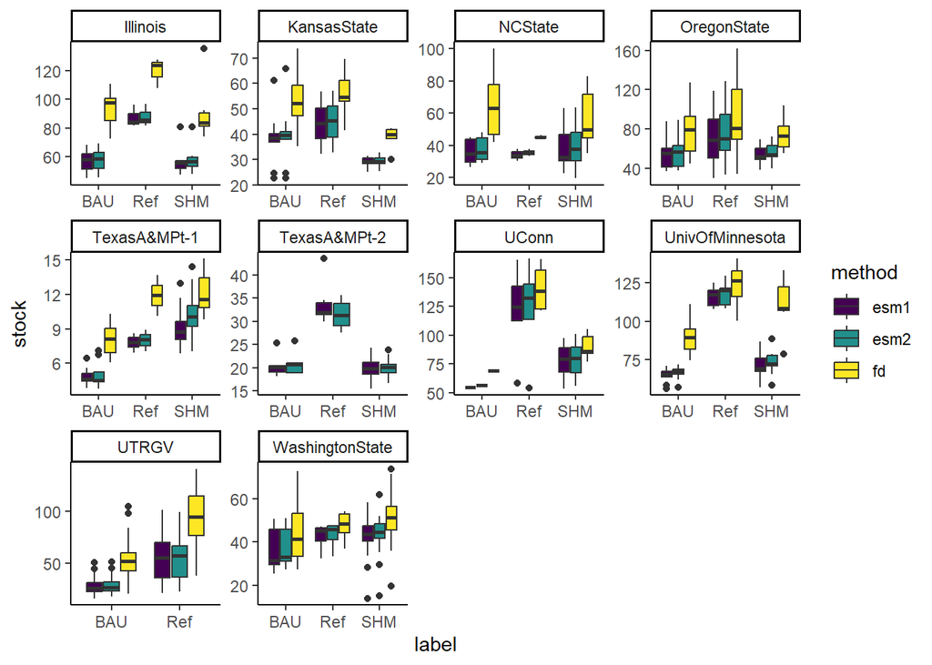

```r
# Pull out the deepest layer for ESM calculations to get cumulative SOC stock
esm1_deepest <- esm1 %>%
  group_by(Campaign, Treatment, Point) %>%
  filter(Lower_cm == min(Lower_cm)) %>%
  ungroup()

esm2_deepest <- esm2 %>%
  group_by(Campaign, Treatment, Point) %>%
  filter(Lower_cm == min(Lower_cm)) %>%
  ungroup()

# Make table with fixed depth SOC stocks and ESM SOC stocks
soc_stock30_compare <- soc_pedon %>%
  select(project, dsp_pedon_id, label, soc_stock_0_30cm) %>%
  rename(stock_fd = soc_stock_0_30cm) %>%
  mutate(depth_fd = -30)%>%
  left_join(select(esm1_deepest, Point, Lower_cm, SOC_stock_cum_ESM), by=c("dsp_pedon_id" = "Point")) %>%
  rename(stock_esm1 = SOC_stock_cum_ESM,
         depth_esm1 = Lower_cm) %>%
  left_join(select(esm2_deepest, Point, Lower_cm, SOC_stock_cum_ESM2), by=c("dsp_pedon_id" = "Point")) %>%
  rename(stock_esm2 = SOC_stock_cum_ESM2,
         depth_esm2 = Lower_cm) %>%
  pivot_longer(cols = stock_fd:stock_esm2,
               names_to = c(".value", "method"),
               names_sep="_"
               )

# Plot comparison of stocks
ggplot(soc_stock30_compare, aes(x=label, y=stock, fill=method)) +
  geom_boxplot() +
  facet_wrap(~project, scales="free") +
  scale_fill_viridis(discrete=TRUE) +
  theme_classic()
```

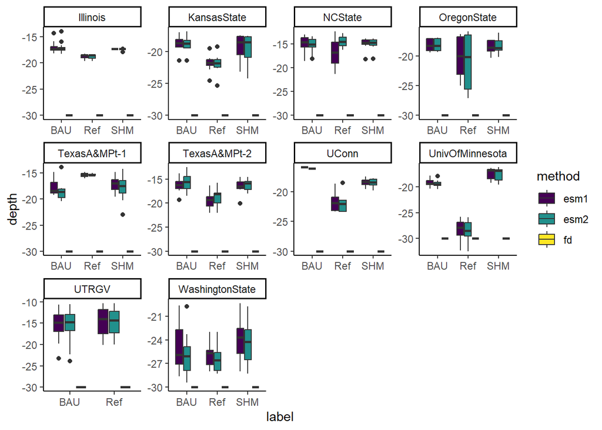

```r
# Plot comparison of depths used
ggplot(soc_stock30_compare, aes(x=label, y=depth, fill=method)) +
  geom_boxplot() +
  facet_wrap(~project, scales="free") +
  scale_fill_viridis(discrete=TRUE) +
  theme_classic()
```

The SOC stocks calculated with fixed depths are much higher than the SOC stocks calculated with ESM. However, I’m not certain how comparable these values really are.

```r
max(soc_stock30_compare$depth)
```

```
## [1] -10.28417
```

The shallowest depth used by ESM to calculate total SOC stocks is 10 cm. Even with differences in bulk density between soils, it doesn’t seem right to compare stocks to 10 cm depth to stocks to 30 cm depth. I think that some of the differences in total SOC stocks between methods is an artifact of comparing very different soils to each other, rather than reflecting real differences in bulk density driven by management.

Also, looking at the Texas A&M Pt2 data - they didn’t measure SOC below 22 cm in most cases - I wonder if the inclusion of those shallow samples is the reason that the ESM calculations are really shallow.

# ESM calculations without the Texas A&M Pt 2 data

Read in output of SimpleESM script with no TAM2 data

```r
fd_no_tam2 <- read.csv(here("data_processed", "simple_esm", "Output_FD_no_tam2.csv"), sep = ";")
esm1_no_tam2 <- read.csv(here("data_processed", "simple_esm", "Output_ESM_no_tam2.csv"), sep = ";")
esm2_no_tam2 <- read.csv(here("data_processed", "simple_esm", "Output_ESM2_no_tam2.csv"), sep = ";")

min(esm1_no_tam2$Lower_cm)
```

```
## [1] -37
```

Getting a little bit deeper - now the deepest ESM depth is 37 cm. Next, try to get deeper calculations by looking at only one project.

# ESM calculations with only Oregon State data

```r
fd_osu <- read.csv(here("data_processed", "simple_esm", "Output_FD_osu.csv"), sep = ";")
esm1_osu <- read.csv(here("data_processed", "simple_esm", "Output_ESM_osu.csv"), sep = ";")
esm2_osu <- read.csv(here("data_processed", "simple_esm", "Output_ESM2_osu.csv"), sep = ";")

min(esm1_osu$Lower_cm)
```

```
## [1] -30.2
```

Now the deepest depth is 30.2 cm - seems like the script defaults to only going down to 30 cm if auto method is used? I can’t figure out why that would be the case from looking at the script. I’m also not sure why there are only 3 layers. Ideally, I would like to get ESM calculations for ~5 layers, and would like calculated stocks down to 100 cm.

Comparison of total SOC stocks calculated ESM classic, ESM spline, and fixed depth methods:

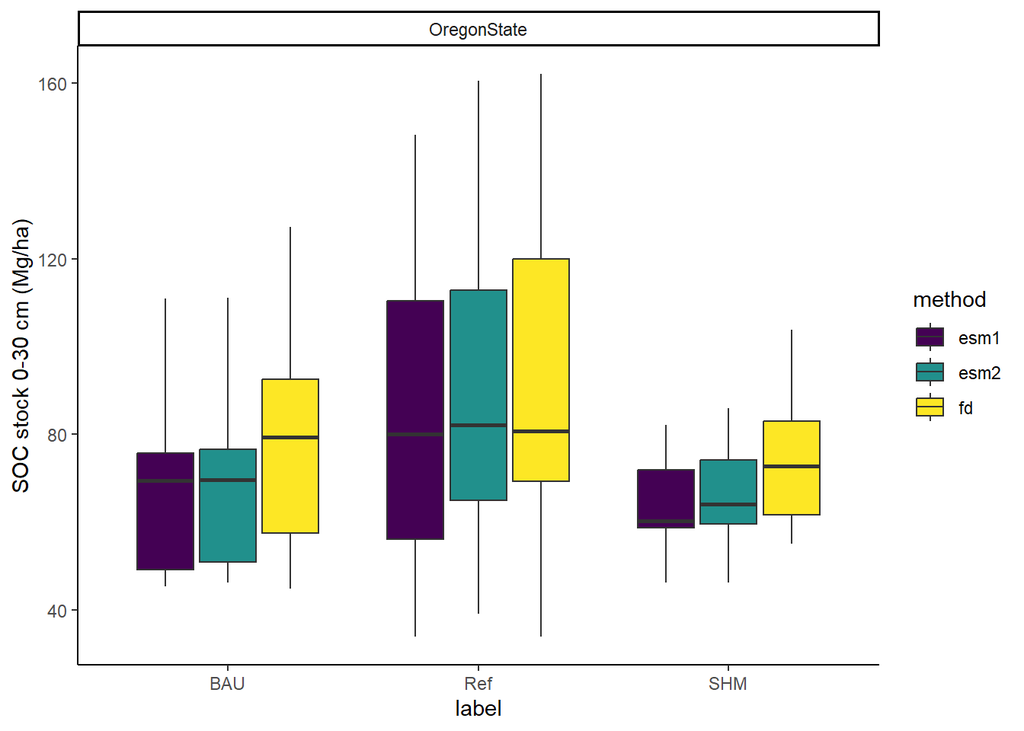

```r
# Compare our FD calcs to ESM calcs
esm1_deepest_osu <- esm1_osu %>%
  group_by(Campaign, Treatment, Point) %>%
  filter(Lower_cm == min(Lower_cm)) %>%
  ungroup()

esm2_deepest_osu <- esm2_osu %>%
  group_by(Campaign, Treatment, Point) %>%
  filter(Lower_cm == min(Lower_cm)) %>%
  ungroup()

compare_osu <- soc_pedon %>%
  filter(project=="OregonState") %>%
  select(project, dsp_pedon_id, label, soc_stock_0_30cm) %>%
  rename(stock_fd = soc_stock_0_30cm) %>%
  mutate(depth_fd = -30)%>%
  left_join(select(esm1_deepest_osu, Point, Lower_cm, SOC_stock_cum_ESM), by=c("dsp_pedon_id" = "Point")) %>%
  rename(stock_esm1 = SOC_stock_cum_ESM,
         depth_esm1 = Lower_cm) %>%
  left_join(select(esm2_deepest_osu, Point, Lower_cm, SOC_stock_cum_ESM2), by=c("dsp_pedon_id" = "Point")) %>%
  rename(stock_esm2 = SOC_stock_cum_ESM2,
         depth_esm2 = Lower_cm) %>%
  pivot_longer(cols = stock_fd:stock_esm2,
               names_to = c(".value", "method"),
               names_sep="_"
  )

# Plot comparison of stocks
ggplot(compare_osu, aes(x=label, y=stock, fill=method)) +
  geom_boxplot() +
  labs(y="SOC stock 0-30 cm (Mg/ha)") +
  facet_wrap(~project, scales="free") +
  scale_fill_viridis(discrete=TRUE) +
  theme_classic()
```

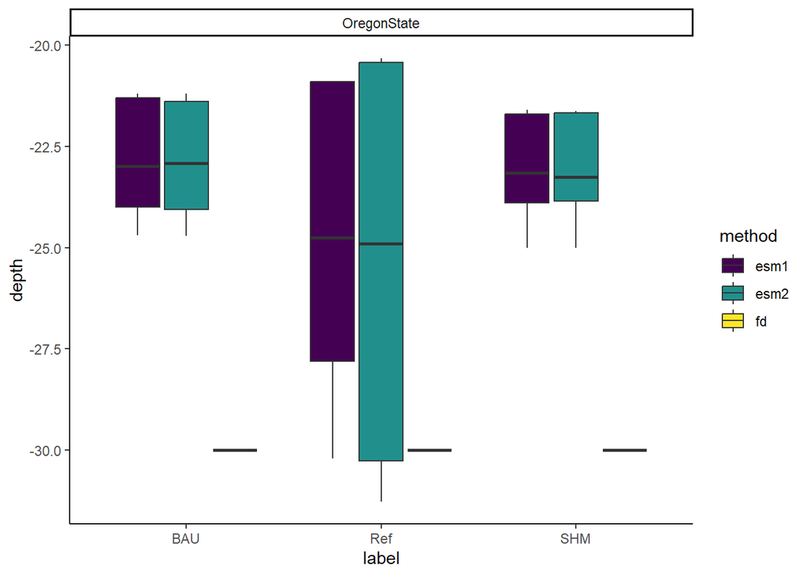

```r
# Plot comparison of depths used
ggplot(compare_osu, aes(x=label, y=depth, fill=method)) +
  geom_boxplot() +
  facet_wrap(~project, scales="free") +
  scale_fill_viridis(discrete=TRUE) +
  theme_classic()
```

Now there appears to be less of a difference between FD and ESM methods. The difference between this figure and the previous figure is that reference masses were calculated only from OSU data, rather than the entire DSP4SH dataset.

# ESM calculations with only Oregon State data - manual reference mass calculation

In order to get deeper soil depths, try including the reference soil mass in the input to SimpleESM.

First we will need to calculate reasonable reference soil masses to use. Let’s use 5 layers: 0-10 cm, 10-30 cm, 30-50 cm, 50-75 cm, and 75-100 cm.

```r
# Extract data from the SoilProfileCollection back into a dataframe and calculate soil mass in each 1-cm increment
spc_osu <- soc_horizon %>% filter(project=="OregonState")
depths(spc_osu) <- dsp_pedon_id ~ hrzdep_t + hrzdep_b #make data a SoilProfileCollection, get depths from hrzdep_t and hrzdep_b columns
hzdesgnname(spc_osu) <- 'hzdesg' #get horizon names from hzdesg column

# Use dice() function to resample profile into 1 cm increments, keeping the variables needed for SOC stock calculation
dice_osu <- aqp::dice(spc_osu, fm=0:100 ~ soc_fill + bd_fill + coarse_frag_fill)

# calculate mass of each 1-cm horizon
mass_osu <- horizons(dice_osu) %>%
  mutate(mass = (hrzdep_b - hrzdep_t) * bd_fill * 100) # 1 g/cm2 = 100 megagrams ha

# 0-10 cm depth sum
mass0_10_osu <- mass_osu %>%
  filter(hrzdep_t < 10) %>%
  group_by(dsp_pedon_id) %>%
  summarize(mass_tot10 = sum(mass))

# 10-30 cm depth sum
mass10_30_osu <- mass_osu %>%
  filter(hrzdep_t >=10 & hrzdep_t < 30) %>%
  group_by(dsp_pedon_id) %>%
  summarize(mass_tot30 = sum(mass))

# 30-50 cm depth sum
mass30_50_osu <- mass_osu %>%
  filter(hrzdep_t >=30 & hrzdep_t < 50) %>%
  group_by(dsp_pedon_id) %>%
  summarize(mass_tot50 = sum(mass))

# 50-75 cm depth sum
mass50_75_osu <- mass_osu %>%
  filter(hrzdep_t >=50 & hrzdep_t < 75) %>%
  group_by(dsp_pedon_id) %>%
  summarize(mass_tot75 = sum(mass))

# 75-100 cm depth sum
mass75_100_osu <- mass_osu %>%
  filter(hrzdep_t >=75 & hrzdep_t < 100) %>%
  group_by(dsp_pedon_id) %>%
  summarize(mass_tot100 = sum(mass))

# Join together into one dataframe and calculate min soil mass in each depth
mass_min_osu <- mass0_10_osu %>%
  left_join(mass10_30_osu, by="dsp_pedon_id") %>%
  left_join(mass30_50_osu, by="dsp_pedon_id") %>%
  left_join(mass50_75_osu, by="dsp_pedon_id") %>%
  left_join(mass75_100_osu, by="dsp_pedon_id") %>%
  summarize(across(mass_tot10:mass_tot100, ~min(.x, na.rm=TRUE)))
```

Here, I used minimum soil mass in each layer as reference mass. I copied these values into the SimpleESM input Excel sheet and re-ran the script using the manual reference mass calculation method. I don’t know that using the minimum soil mass in each layer is the best way to choose a reference mass. I just needed something to work with.

```r
fd_osu_manual <- read.csv(here("data_processed", "simple_esm", "Output_FD_osu_manual.csv"), sep = ";")
esm1_osu_manual <- read.csv(here("data_processed", "simple_esm", "Output_ESM_osu_manual.csv"), sep = ";") %>%
  unite("sample_id", Point:Layer, sep="-", remove=FALSE)
esm2_osu_manual <- read.csv(here("data_processed", "simple_esm", "Output_ESM2_osu_manual.csv"), sep = ";") %>%
  unite("sample_id", Point:Layer, sep="-", remove=FALSE)

min(esm1_osu_manual$Lower_cm)
```

```
## [1] -90.7
```

The deepest depth is now 90 cm :) Mission accomplished!

In order to compare the ESM methods to our fixed depth SOC calculations, will need to recalculate SOC stocks at depth intervals that match what we fed SimpleESM:

```r
# Calculate SOC in each horizon
soc_osu <- horizons(dice_osu) %>%
  mutate(hrzdepth = hrzdep_b - hrzdep_t,
         cf_mult = 1 - (coarse_frag_fill/100)) %>%
  mutate(soc_stock_hrz = soc_fill * bd_fill * hrzdepth * cf_mult)

# 0-10 cm depth sum
soc0_10_osu <- soc_osu %>%
  filter(hrzdep_t < 10) %>%
  group_by(dsp_pedon_id) %>%
  summarize(soc_tot10 = sum(soc_stock_hrz))

# 10-30 cm depth sum
soc10_30_osu <- soc_osu %>%
  filter(hrzdep_t >=10 & hrzdep_t < 30) %>%
  group_by(dsp_pedon_id) %>%
  summarize(soc_tot30 = sum(soc_stock_hrz))

# 30-50 cm depth sum
soc30_50_osu <- soc_osu %>%
  filter(hrzdep_t >=30 & hrzdep_t < 50) %>%
  group_by(dsp_pedon_id) %>%
  summarize(soc_tot50 = sum(soc_stock_hrz))

# 50-75 cm depth sum
soc50_75_osu <- soc_osu %>%
  filter(hrzdep_t >=50 & hrzdep_t < 75) %>%
  group_by(dsp_pedon_id) %>%
  summarize(soc_tot75 = sum(soc_stock_hrz))

# 75-100 cm depth sum
soc75_100_osu <- soc_osu %>%
  filter(hrzdep_t >=75 & hrzdep_t < 100) %>%
  group_by(dsp_pedon_id) %>%
  summarize(soc_tot100 = sum(soc_stock_hrz))

# join into one dataframe
soc_tot_osu <- soc0_10_osu %>%
  left_join(soc10_30_osu, by="dsp_pedon_id") %>%
  left_join(soc30_50_osu, by="dsp_pedon_id") %>%
  left_join(soc50_75_osu, by="dsp_pedon_id") %>%
  left_join(soc75_100_osu, by="dsp_pedon_id") %>%
  pivot_longer(cols = soc_tot10:soc_tot100,
               names_to = c(".value", "depth"),
               names_sep="_"
               ) %>%
  group_by(dsp_pedon_id) %>%
  mutate(depth_fd = ifelse(depth=="tot10", -10,
                        ifelse(depth=="tot30", -30,
                               ifelse(depth=="tot50", -50,
                                      ifelse(depth=="tot75", -75, -100))))) %>%
  mutate(layer=ifelse(depth=="tot10", 1,
                      ifelse(depth=="tot30", 2,
                             ifelse(depth=="tot50", 3,
                                    ifelse(depth=="tot75", 4, 5))))) %>%
  select(-depth) %>%
  unite("sample_id", c("dsp_pedon_id", "layer"), sep="-", remove=FALSE) %>%
  rename(soc_fd = soc) %>%
  ungroup()
```

Join and compare to ESM calculations:

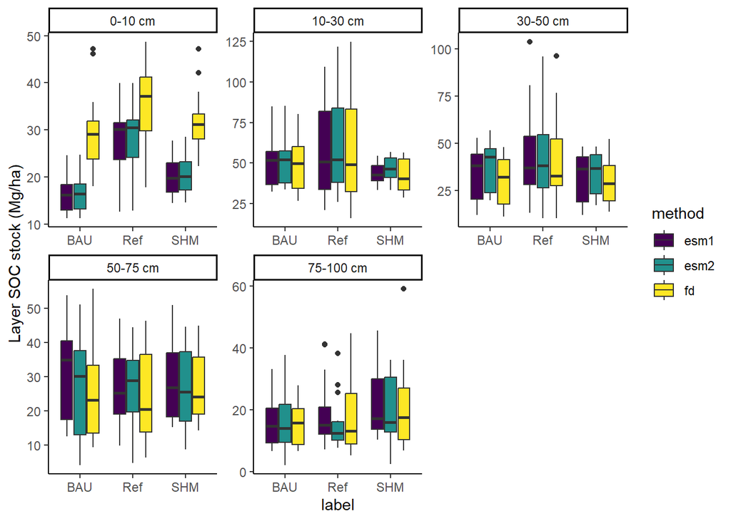

```r
compare_osu_manual <- esm1_osu_manual %>%
  select(Campaign, Treatment, Point, sample_id,Layer, Lower_cm, SOC_stock_ESM) %>%
  rename(project = Campaign,
         label=Treatment,
         dsp_pedon_id = Point,
         depth_esm1 = Lower_cm,
         soc_esm1 = SOC_stock_ESM) %>%
  left_join(select(esm2_osu_manual,
                   sample_id, Lower_cm, SOC_stock_ESM2), by="sample_id") %>%
  rename(soc_esm2 = SOC_stock_ESM2,
         depth_esm2 = Lower_cm) %>%
  left_join(select(soc_tot_osu, sample_id, soc_fd, depth_fd), by="sample_id") %>%
  pivot_longer(cols = depth_esm1:depth_fd,
               names_to = c(".value", "method"),
               names_sep="_"
               )

# Plot comparison of SOC stocks in each layer
# Labels for layers
layer_labels <- c("1" = "0-10 cm",
                  "2" = "10-30 cm",
                  "3" = "30-50 cm",
                  "4" = "50-75 cm",
                  "5" = "75-100 cm")

ggplot(compare_osu_manual %>% filter(dsp_pedon_id !="JoV2-3"), # filter out one sample that only has shallow values
       aes(x=label, y=soc, fill=method)) +
  geom_boxplot() +
  labs(y="Layer SOC stock (Mg/ha)") +
  facet_wrap(~Layer, scales="free", labeller = labeller(Layer = layer_labels)) +
  scale_fill_viridis(discrete=TRUE) +
  theme_classic()
```

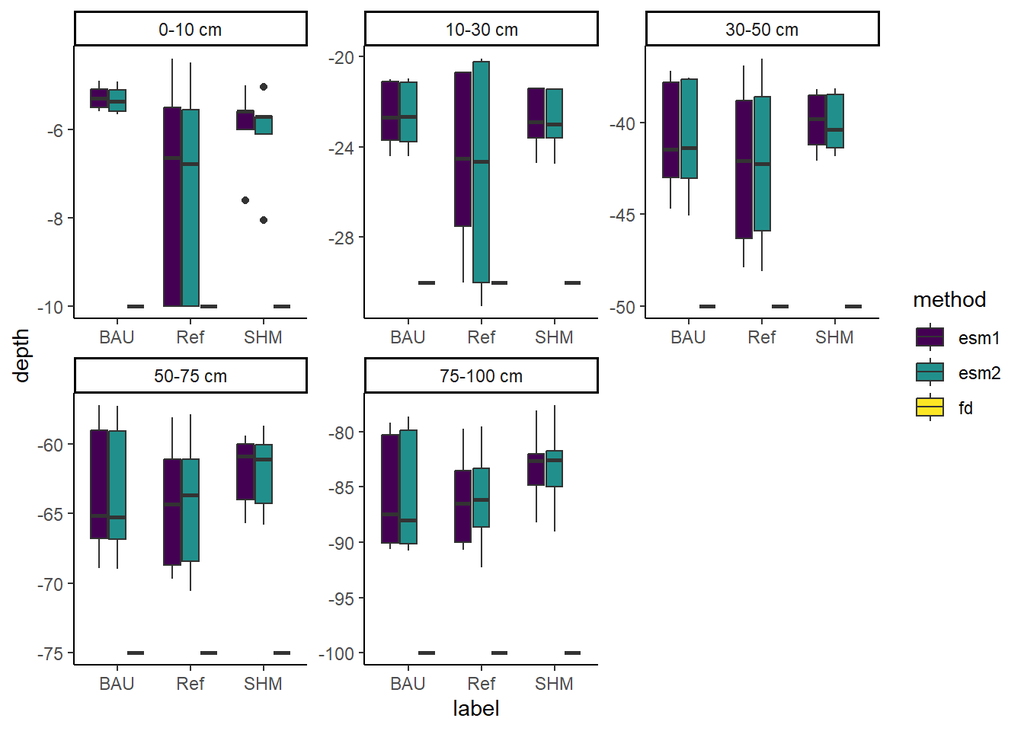

```r
# Plot comparison of depths used
ggplot(compare_osu_manual%>% filter(dsp_pedon_id !="JoV2-3"), # filter out one sample that only has shallow values
       aes(x=label, y=depth, fill=method)) +
  geom_boxplot() +
  facet_wrap(~Layer, scales="free", labeller = labeller(Layer = layer_labels)) +
  scale_fill_viridis(discrete=TRUE) +
  theme_classic()
```

This is pretty interesting - by looking at the SOC stocks in each layer, we see that the big difference between the ESM calculations and fixed depth calculations is in the first layer (0-10 cm). This makes sense, as it is the most sensitive to management and the layer where bulk density is the most dynamic. SOC stocks calculated by ESM methods are quite lower compared to the fixed depth calculation. This might change depending on our choice of reference mass.

Importantly, at least in this project, using ESM to calculate SOC stocks doesn’t change the patterns in SOC stocks across treatments. If anything, there appears to be a bigger difference between Ref and BAU/SHM in the 0-10 cm layer when SOC stocks are calculated using ESM vs. FD. Using ESM does change the absolute value of the calculated SOC stock. I am curious about how selecting a different reference mass - say, the average mass in the BAU treatment - might change these calculations.